# Enron fraud project

### Dataset

In 2000, Enron was one of the largest companies in the United States. By 2002, it had collapsed into bankruptcy due to widespread corporate fraud. In the resulting Federal investigation, there was a significant amount of typically confidential information entered into public record, including tens of thousands of emails and detailed financial data for top executives.

In this project, we will play detectiveand and use machine learning skills to build a person of interest identifier based on financial and email data. To assist the detective work, a hand-generated list of persons of interest in the fraud case is provided, which means individuals who were indicted, reached a settlement, or plea deal with the government, or testified in exchange for prosecution immunity.

The features in the data fall into three major types, namely financial features, email features and POI labels.

- financial features: ['salary', 'deferral_payments', 'total_payments', 'loan_advances', 'bonus', 'restricted_stock_deferred', 'deferred_income', 'total_stock_value', 'expenses', 'exercised_stock_options', 'other', 'long_term_incentive', 'restricted_stock', 'director_fees'] (all units are in US dollars)
- email features: ['to_messages', 'email_address', 'from_poi_to_this_person', 'from_messages', 'from_this_person_to_poi', 'shared_receipt_with_poi'] (units are generally number of emails messages; notable exception is ‘email_address’, which is a text string)
- POI label: [‘poi’] (boolean, represented as integer)

```python
import numpy as np
import pandas as pd
import sys
import pickle
sys.path.append("tools/")
import matplotlib.pyplot as plt
%matplotlib inline
import seaborn as sb
from time import time

from sklearn.model_selection import train_test_split
from sklearn.metrics import accuracy_score
from sklearn.metrics import precision_score
from sklearn.metrics import recall_score
```

## 0. Required functions

```python
from feature_format import featureFormat, targetFeatureSplit
from tester import dump_classifier_and_data
```

### featureFormat & targetFeatureSplit

(from Udacity - Intro to ML)

A general tool for converting data from the dictionary format to an (n x k) python list that's ready for training an sklearn algorithm

n--no. of key-value pairs in dictonary

k--no. of features being extracted

dictionary keys are names of persons in dataset

dictionary values are dictionaries, where each key-value pair in the dict is the name of a feature, and its value for that person

In addition to converting a dictionary to a numpy array, you may want to separate the labels from the features--this is what targetFeatureSplit is for

So, if you want to have the poi label as the target, and the features you want to use are the person's salary and bonus, here's what you would do:

feature_list = ["poi", "salary", "bonus"]

data_array = featureFormat( data_dictionary, feature_list )

label, features = targetFeatureSplit(data_array)

the line above (targetFeatureSplit) assumes that the label is the *first* item in feature_list--very important that poi is listed first!

### tester

(from Udacity - Intro to ML)

a basic script for importing student's POI identifier, and checking the results that they get from it

requires that the algorithm, dataset, and features list be written to my_classifier.pkl, my_dataset.pkl, and my_feature_list.pkl, respectively

that process should happen at the end of poi_id.py

## 1. Download data, check its structure & make dataframe out of it

```python
### Load the dictionary containing the dataset
with open("final_project_dataset.pkl", "r") as data_file:
    data_dict = pickle.load(data_file)
```

```python
#data_dict.keys()
```

```python
# Number of people in Enron dataset
len(data_dict.keys())
```

```
146
```

```python
# Number of features in dictionary
len(data_dict[data_dict.keys()[0]])
```

```
21
```

How many guilty people are in the dataset?

```python
count=0
for i in data_dict.keys():
    #print enron_data[i]['poi']
    if data_dict[i]['poi']==True:
        count=count+1
count
```

```
18
```

Convert enron_data to dataframe

```python
data_dict['METTS MARK'].keys()
```

```
['salary',
 'to_messages',
 'deferral_payments',
 'total_payments',
 'exercised_stock_options',
 'bonus',
 'restricted_stock',
 'shared_receipt_with_poi',
 'restricted_stock_deferred',
 'total_stock_value',
 'expenses',
 'loan_advances',
 'from_messages',
 'other',
 'from_this_person_to_poi',
 'poi',
 'director_fees',
 'deferred_income',
 'long_term_incentive',
 'email_address',
 'from_poi_to_this_person']
```

```python
features_list= ['salary', 'to_messages',  'deferral_payments',
                'total_payments', 'exercised_stock_options',
                'bonus', 'restricted_stock', 'shared_receipt_with_poi',
                'restricted_stock_deferred', 'total_stock_value',
                'expenses', 'loan_advances', 'from_messages',
                'other', 'from_this_person_to_poi', 'poi',
                'director_fees', 'deferred_income', 'long_term_incentive',
                'from_poi_to_this_person']
```

```python
data=featureFormat(data_dict, features_list, remove_NaN=False, remove_all_zeroes=False, remove_any_zeroes=False, sort_keys = False)
target, features=targetFeatureSplit( data )
```

```python
## make dataframe from the enron_data
enron_df=pd.DataFrame(data, columns=features_list )

xx=True
if xx==True:
    ## add person name to df
    enron_df['name']=data_dict.keys()
    ## add person email to df
    enron_df['email_address']=np.nan
    for i in data_dict.keys():
        enron_df.loc[enron_df['name']==i, 'email_address']= data_dict[i]['email_address']
enron_df.head()
```

|  | salary | to_messages | deferral_payments | total_payments | exercised_stock_options | bonus | restricted_stock | shared_receipt_with_poi | restricted_stock_deferred | total_stock_value | ... | from_messages | other | from_this_person_to_poi | poi | director_fees | deferred_income | long_term_incentive | from_poi_to_this_person | name | email_address |
| --- | --- | --- | --- | --- | --- | --- | --- | --- | --- | --- | --- | --- | --- | --- | --- | --- | --- | --- | --- | --- | --- |
| 0 | 365788.0 | 807.0 | NaN | 1061827.0 | NaN | 600000.0 | 585062.0 | 702.0 | NaN | 585062.0 | ... | 29.0 | 1740.0 | 1.0 | 0.0 | NaN | NaN | NaN | 38.0 | METTS MARK | mark.metts@enron.com |
| 1 | 267102.0 | NaN | 1295738.0 | 5634343.0 | 6680544.0 | 1200000.0 | 3942714.0 | NaN | NaN | 10623258.0 | ... | NaN | 2660303.0 | NaN | 0.0 | NaN | -1386055.0 | 1586055.0 | NaN | BAXTER JOHN C | NaN |
| 2 | 170941.0 | NaN | NaN | 211725.0 | 4890344.0 | 350000.0 | 1788391.0 | NaN | NaN | 6678735.0 | ... | NaN | 12961.0 | NaN | 0.0 | NaN | -400729.0 | NaN | NaN | ELLIOTT STEVEN | steven.elliott@enron.com |
| 3 | NaN | 764.0 | NaN | NaN | 651850.0 | NaN | 386335.0 | 58.0 | NaN | 1038185.0 | ... | 12.0 | NaN | 0.0 | 0.0 | NaN | NaN | NaN | 10.0 | CORDES WILLIAM R | bill.cordes@enron.com |
| 4 | 243293.0 | 1045.0 | NaN | 288682.0 | 5538001.0 | 1500000.0 | 853064.0 | 1035.0 | NaN | 6391065.0 | ... | 32.0 | 11350.0 | 21.0 | 1.0 | NaN | -3117011.0 | 1617011.0 | 32.0 | HANNON KEVIN P | kevin.hannon@enron.com |

5 rows × 22 columns

## 2. Clean dataframe: Remove outliers and strange records

```python
# remove 'poi' from features_list for further analysis
features_list.remove('poi')
```

```python
enron_df.describe()
```

|  | salary | to_messages | deferral_payments | total_payments | exercised_stock_options | bonus | restricted_stock | shared_receipt_with_poi | restricted_stock_deferred | total_stock_value | expenses | loan_advances | from_messages | other | from_this_person_to_poi | poi | director_fees | deferred_income | long_term_incentive | from_poi_to_this_person |
| --- | --- | --- | --- | --- | --- | --- | --- | --- | --- | --- | --- | --- | --- | --- | --- | --- | --- | --- | --- | --- |
| count | 9.500000e+01 | 86.000000 | 3.900000e+01 | 1.250000e+02 | 1.020000e+02 | 8.200000e+01 | 1.100000e+02 | 86.000000 | 1.800000e+01 | 1.260000e+02 | 9.500000e+01 | 4.000000e+00 | 86.000000 | 9.300000e+01 | 86.000000 | 146.000000 | 1.700000e+01 | 4.900000e+01 | 6.600000e+01 | 86.000000 |
| mean | 5.621943e+05 | 2073.860465 | 1.642674e+06 | 5.081526e+06 | 5.987054e+06 | 2.374235e+06 | 2.321741e+06 | 1176.465116 | 1.664106e+05 | 6.773957e+06 | 1.087289e+05 | 4.196250e+07 | 608.790698 | 9.190650e+05 | 41.232558 | 0.123288 | 1.668049e+05 | -1.140475e+06 | 1.470361e+06 | 64.895349 |
| std | 2.716369e+06 | 2582.700981 | 5.161930e+06 | 2.906172e+07 | 3.106201e+07 | 1.071333e+07 | 1.251828e+07 | 1178.317641 | 4.201494e+06 | 3.895777e+07 | 5.335348e+05 | 4.708321e+07 | 1841.033949 | 4.589253e+06 | 100.073111 | 0.329899 | 3.198914e+05 | 4.025406e+06 | 5.942759e+06 | 86.979244 |
| min | 4.770000e+02 | 57.000000 | -1.025000e+05 | 1.480000e+02 | 3.285000e+03 | 7.000000e+04 | -2.604490e+06 | 2.000000 | -7.576788e+06 | -4.409300e+04 | 1.480000e+02 | 4.000000e+05 | 12.000000 | 2.000000e+00 | 0.000000 | 0.000000 | 3.285000e+03 | -2.799289e+07 | 6.922300e+04 | 0.000000 |
| 25% | 2.118160e+05 | 541.250000 | 8.157300e+04 | 3.944750e+05 | 5.278862e+05 | 4.312500e+05 | 2.540180e+05 | 249.750000 | -3.896218e+05 | 4.945102e+05 | 2.261400e+04 | 1.600000e+06 | 22.750000 | 1.215000e+03 | 1.000000 | 0.000000 | 9.878400e+04 | -6.948620e+05 | 2.812500e+05 | 10.000000 |
| 50% | 2.599960e+05 | 1211.000000 | 2.274490e+05 | 1.101393e+06 | 1.310814e+06 | 7.693750e+05 | 4.517400e+05 | 740.500000 | -1.469750e+05 | 1.102872e+06 | 4.695000e+04 | 4.176250e+07 | 41.000000 | 5.238200e+04 | 8.000000 | 0.000000 | 1.085790e+05 | -1.597920e+05 | 4.420350e+05 | 35.000000 |
| 75% | 3.121170e+05 | 2634.750000 | 1.002672e+06 | 2.093263e+06 | 2.547724e+06 | 1.200000e+06 | 1.002370e+06 | 1888.250000 | -7.500975e+04 | 2.949847e+06 | 7.995250e+04 | 8.212500e+07 | 145.500000 | 3.620960e+05 | 24.750000 | 0.000000 | 1.137840e+05 | -3.834600e+04 | 9.386720e+05 | 72.250000 |
| max | 2.670423e+07 | 15149.000000 | 3.208340e+07 | 3.098866e+08 | 3.117640e+08 | 9.734362e+07 | 1.303223e+08 | 5521.000000 | 1.545629e+07 | 4.345095e+08 | 5.235198e+06 | 8.392500e+07 | 14368.000000 | 4.266759e+07 | 609.000000 | 1.000000 | 1.398517e+06 | -8.330000e+02 | 4.852193e+07 | 528.000000 |

we see that there are a lot of missing values in this data and there are some negative values. This should be checked.

```python
enron_df[enron_df['deferral_payments']<0]
```

|  | salary | to_messages | deferral_payments | total_payments | exercised_stock_options | bonus | restricted_stock | shared_receipt_with_poi | restricted_stock_deferred | total_stock_value | ... | from_messages | other | from_this_person_to_poi | poi | director_fees | deferred_income | long_term_incentive | from_poi_to_this_person | name | email_address |
| --- | --- | --- | --- | --- | --- | --- | --- | --- | --- | --- | --- | --- | --- | --- | --- | --- | --- | --- | --- | --- | --- |
| 24 | NaN | NaN | -102500.0 | 102500.0 | 3285.0 | NaN | NaN | NaN | 44093.0 | -44093.0 | ... | NaN | NaN | NaN | 0.0 | 3285.0 | NaN | NaN | NaN | BELFER ROBERT | NaN |

1 rows × 22 columns

```python
enron_df[enron_df['restricted_stock']<0]
```

|  | salary | to_messages | deferral_payments | total_payments | exercised_stock_options | bonus | restricted_stock | shared_receipt_with_poi | restricted_stock_deferred | total_stock_value | ... | from_messages | other | from_this_person_to_poi | poi | director_fees | deferred_income | long_term_incentive | from_poi_to_this_person | name | email_address |
| --- | --- | --- | --- | --- | --- | --- | --- | --- | --- | --- | --- | --- | --- | --- | --- | --- | --- | --- | --- | --- | --- |
| 118 | NaN | 523.0 | NaN | 15456290.0 | 2604490.0 | NaN | -2604490.0 | 463.0 | 15456290.0 | NaN | ... | 29.0 | 137864.0 | 1.0 | 0.0 | 137864.0 | NaN | NaN | 0.0 | BHATNAGAR SANJAY | sanjay.bhatnagar@enron.com |

1 rows × 22 columns

```python
enron_df[enron_df['restricted_stock_deferred']<0].shape[0]
```

```
16
```

```python
enron_df[enron_df['total_stock_value']<0]
```

|  | salary | to_messages | deferral_payments | total_payments | exercised_stock_options | bonus | restricted_stock | shared_receipt_with_poi | restricted_stock_deferred | total_stock_value | ... | from_messages | other | from_this_person_to_poi | poi | director_fees | deferred_income | long_term_incentive | from_poi_to_this_person | name | email_address |
| --- | --- | --- | --- | --- | --- | --- | --- | --- | --- | --- | --- | --- | --- | --- | --- | --- | --- | --- | --- | --- | --- |
| 24 | NaN | NaN | -102500.0 | 102500.0 | 3285.0 | NaN | NaN | NaN | 44093.0 | -44093.0 | ... | NaN | NaN | NaN | 0.0 | 3285.0 | NaN | NaN | NaN | BELFER ROBERT | NaN |

1 rows × 22 columns

```python
enron_df[enron_df['deferred_income']<0].head(15)
```

|  | salary | to_messages | deferral_payments | total_payments | exercised_stock_options | bonus | restricted_stock | shared_receipt_with_poi | restricted_stock_deferred | total_stock_value | ... | from_messages | other | from_this_person_to_poi | poi | director_fees | deferred_income | long_term_incentive | from_poi_to_this_person | name | email_address |
| --- | --- | --- | --- | --- | --- | --- | --- | --- | --- | --- | --- | --- | --- | --- | --- | --- | --- | --- | --- | --- | --- |
| 1 | 267102.0 | NaN | 1295738.0 | 5634343.0 | 6680544.0 | 1200000.0 | 3942714.0 | NaN | NaN | 10623258.0 | ... | NaN | 2660303.0 | NaN | 0.0 | NaN | -1386055.0 | 1586055.0 | NaN | BAXTER JOHN C | NaN |
| 2 | 170941.0 | NaN | NaN | 211725.0 | 4890344.0 | 350000.0 | 1788391.0 | NaN | NaN | 6678735.0 | ... | NaN | 12961.0 | NaN | 0.0 | NaN | -400729.0 | NaN | NaN | ELLIOTT STEVEN | steven.elliott@enron.com |
| 4 | 243293.0 | 1045.0 | NaN | 288682.0 | 5538001.0 | 1500000.0 | 853064.0 | 1035.0 | NaN | 6391065.0 | ... | 32.0 | 11350.0 | 21.0 | 1.0 | NaN | -3117011.0 | 1617011.0 | 32.0 | HANNON KEVIN P | kevin.hannon@enron.com |
| 9 | 197091.0 | 1238.0 | 1130036.0 | 1737629.0 | 880290.0 | 400000.0 | 409554.0 | 742.0 | -409554.0 | 880290.0 | ... | 222.0 | 778.0 | 48.0 | 0.0 | NaN | -33333.0 | NaN | 61.0 | PIPER GREGORY F | greg.piper@enron.com |
| 16 | 288542.0 | 1758.0 | 27610.0 | 1490344.0 | NaN | 1200000.0 | 698242.0 | 1132.0 | NaN | 698242.0 | ... | 40.0 | 101740.0 | 11.0 | 1.0 | NaN | -144062.0 | NaN | 240.0 | COLWELL WESLEY | wes.colwell@enron.com |
| 17 | 251654.0 | 136.0 | 842924.0 | 3202070.0 | 1056320.0 | 1100000.0 | 360528.0 | 114.0 | NaN | 1416848.0 | ... | 16.0 | 947.0 | 0.0 | 0.0 | NaN | -719000.0 | 1725545.0 | 12.0 | MULLER MARK S | s..muller@enron.com |
| 19 | 63744.0 | NaN | NaN | 762135.0 | NaN | NaN | 384930.0 | NaN | NaN | 384930.0 | ... | NaN | 401130.0 | NaN | 0.0 | NaN | -10800.0 | 256191.0 | NaN | WESTFAHL RICHARD K | dick.westfahl@enron.com |
| 23 | NaN | NaN | NaN | NaN | NaN | NaN | 32460.0 | NaN | -32460.0 | NaN | ... | NaN | NaN | NaN | 0.0 | 98784.0 | -98784.0 | NaN | NaN | CHAN RONNIE | NaN |
| 27 | 187922.0 | 383.0 | NaN | 618850.0 | NaN | 250000.0 | 659249.0 | 233.0 | NaN | 659249.0 | ... | 59.0 | 427316.0 | 0.0 | 0.0 | NaN | -485813.0 | 180250.0 | 4.0 | BERGSIEKER RICHARD P | rick.bergsieker@enron.com |
| 28 | NaN | NaN | NaN | 228656.0 | NaN | NaN | NaN | NaN | NaN | NaN | ... | NaN | NaN | NaN | 0.0 | 36666.0 | -36666.0 | NaN | NaN | URQUHART JOHN A | NaN |
| 30 | 249201.0 | 1328.0 | 214678.0 | 1099100.0 | 1635238.0 | 700000.0 | 283649.0 | 1258.0 | NaN | 1918887.0 | ... | 82.0 | 1950.0 | 48.0 | 1.0 | NaN | -100000.0 | NaN | 35.0 | RIEKER PAULA H | paula.rieker@enron.com |
| 35 | NaN | NaN | NaN | 148.0 | NaN | NaN | NaN | NaN | NaN | NaN | ... | NaN | NaN | NaN | 0.0 | 103750.0 | -103750.0 | NaN | NaN | MENDELSOHN JOHN | NaN |
| 45 | 210500.0 | NaN | 875307.0 | 1204583.0 | 2027865.0 | 425000.0 | 315068.0 | NaN | -315068.0 | 2027865.0 | ... | NaN | 1105.0 | NaN | 0.0 | NaN | -775241.0 | 415657.0 | NaN | DETMERING TIMOTHY J | timothy.detmering@enron.com |
| 47 | NaN | 653.0 | NaN | NaN | NaN | NaN | NaN | 12.0 | NaN | NaN | ... | 26.0 | NaN | 0.0 | 0.0 | 17500.0 | -17500.0 | NaN | 0.0 | POWERS WILLIAM | ken.powers@enron.com |
| 49 | 477.0 | 566.0 | NaN | 916197.0 | 4046157.0 | NaN | 1757552.0 | 465.0 | -560222.0 | 5243487.0 | ... | 29.0 | 864523.0 | 0.0 | 0.0 | NaN | -5104.0 | NaN | 39.0 | BANNANTINE JAMES M | james.bannantine@enron.com |

15 rows × 22 columns

```python
enron_df[enron_df['deferred_income']<0].shape[0]
```

```
49
```

```python
data_dict['BELFER ROBERT']
```

```
{'bonus': 'NaN',
 'deferral_payments': -102500,
 'deferred_income': 'NaN',
 'director_fees': 3285,
 'email_address': 'NaN',
 'exercised_stock_options': 3285,
 'expenses': 'NaN',
 'from_messages': 'NaN',
 'from_poi_to_this_person': 'NaN',
 'from_this_person_to_poi': 'NaN',
 'loan_advances': 'NaN',
 'long_term_incentive': 'NaN',
 'other': 'NaN',
 'poi': False,
 'restricted_stock': 'NaN',
 'restricted_stock_deferred': 44093,
 'salary': 'NaN',
 'shared_receipt_with_poi': 'NaN',
 'to_messages': 'NaN',
 'total_payments': 102500,
 'total_stock_value': -44093}
```

If we compare the dataframe entry with enron61702insiderpay.pdf we can see that values are shifted, so we will change values for BELFER ROBERT manually.

```python
data_dict['BELFER ROBERT']['deferred_income']= -102500
data_dict['BELFER ROBERT']['deferral_payments']= np.nan
data_dict['BELFER ROBERT']['expenses']=3285
data_dict['BELFER ROBERT']['director_fees']= 102500
data_dict['BELFER ROBERT']['total_payments']=3285
data_dict['BELFER ROBERT']['exercised_stock_options']= np.nan
data_dict['BELFER ROBERT']['restricted_stock']=44093
data_dict['BELFER ROBERT']['restricted_stock_deferred']=-44093,
data_dict['BELFER ROBERT']['total_stock_value']= np.nan
```

```python
enron_df.loc[enron_df['name']=='BELFER ROBERT', 'deferred_income']=-102500
enron_df.loc[enron_df['name']=='BELFER ROBERT','deferral_payments']= np.nan
enron_df.loc[enron_df['name']=='BELFER ROBERT','expenses']=3285
enron_df.loc[enron_df['name']=='BELFER ROBERT', 'director_fees']= 102500
enron_df.loc[enron_df['name']=='BELFER ROBERT', 'total_payments']=3285
enron_df.loc[enron_df['name']=='BELFER ROBERT', 'exercised_stock_options']= np.nan
enron_df.loc[enron_df['name']=='BELFER ROBERT', 'restricted_stock']=44093
enron_df.loc[enron_df['name']=='BELFER ROBERT', 'restricted_stock_deferred']=-44093
enron_df.loc[enron_df['name']=='BELFER ROBERT', 'total_stock_value']= np.nan
```

```python
data_dict['BHATNAGAR SANJAY']
```

```
{'bonus': 'NaN',
 'deferral_payments': 'NaN',
 'deferred_income': 'NaN',
 'director_fees': 137864,
 'email_address': 'sanjay.bhatnagar@enron.com',
 'exercised_stock_options': 2604490,
 'expenses': 'NaN',
 'from_messages': 29,
 'from_poi_to_this_person': 0,
 'from_this_person_to_poi': 1,
 'loan_advances': 'NaN',
 'long_term_incentive': 'NaN',
 'other': 137864,
 'poi': False,
 'restricted_stock': -2604490,
 'restricted_stock_deferred': 15456290,
 'salary': 'NaN',
 'shared_receipt_with_poi': 463,
 'to_messages': 523,
 'total_payments': 15456290,
 'total_stock_value': 'NaN'}
```

the same as with previous record. While comparing the dataframe entry with enron61702insiderpay.pdf we can see that values are shifted, so we will change values for BHATNAGAR SANJAY manually.

```python
np.nan
```

```
nan
```

```python
data_dict['BHATNAGAR SANJAY']['other']= np.nan
data_dict['BHATNAGAR SANJAY']['expenses']=137864
data_dict['BHATNAGAR SANJAY']['director_fees']=np.nan
data_dict['BHATNAGAR SANJAY']['total_payments']= 137864
data_dict['BHATNAGAR SANJAY']['exercised_stock_options']= 15456290
data_dict['BHATNAGAR SANJAY']['restricted_stock']=   2604490
data_dict['BHATNAGAR SANJAY']['restricted_stock_deferred']= -2604490
data_dict['BHATNAGAR SANJAY']['total_stock_value']=15456290
```

```python
enron_df.loc[enron_df['name']=='BHATNAGAR SANJAY','other']= np.nan
enron_df.loc[enron_df['name']=='BHATNAGAR SANJAY','expenses']=137864
enron_df.loc[enron_df['name']=='BHATNAGAR SANJAY','director_fees']=np.nan
enron_df.loc[enron_df['name']=='BHATNAGAR SANJAY','total_payments']= 137864
enron_df.loc[enron_df['name']=='BHATNAGAR SANJAY','exercised_stock_options']= 15456290
enron_df.loc[enron_df['name']=='BHATNAGAR SANJAY','restricted_stock']=   2604490
enron_df.loc[enron_df['name']=='BHATNAGAR SANJAY','restricted_stock_deferred']= -2604490
enron_df.loc[enron_df['name']=='BHATNAGAR SANJAY','total_stock_value']=15456290
```

```python
enron_df.describe()
```

|  | salary | to_messages | deferral_payments | total_payments | exercised_stock_options | bonus | restricted_stock | shared_receipt_with_poi | restricted_stock_deferred | total_stock_value | expenses | loan_advances | from_messages | other | from_this_person_to_poi | poi | director_fees | deferred_income | long_term_incentive | from_poi_to_this_person |
| --- | --- | --- | --- | --- | --- | --- | --- | --- | --- | --- | --- | --- | --- | --- | --- | --- | --- | --- | --- | --- |
| count | 9.500000e+01 | 86.000000 | 3.800000e+01 | 1.250000e+02 | 1.010000e+02 | 8.200000e+01 | 1.110000e+02 | 86.000000 | 1.800000e+01 | 1.260000e+02 | 9.700000e+01 | 4.000000e+00 | 86.000000 | 9.200000e+01 | 86.000000 | 146.000000 | 1.600000e+01 | 5.000000e+01 | 6.600000e+01 | 86.000000 |
| mean | 5.621943e+05 | 2073.860465 | 1.688600e+06 | 4.958185e+06 | 6.173545e+06 | 2.374235e+06 | 2.348150e+06 | 1176.465116 | -8.418653e+05 | 6.896976e+06 | 1.079422e+05 | 4.196250e+07 | 608.790698 | 9.275563e+05 | 41.232558 | 0.123288 | 1.748146e+05 | -1.119716e+06 | 1.470361e+06 | 64.895349 |
| std | 2.716369e+06 | 2582.700981 | 5.223140e+06 | 2.905005e+07 | 3.122316e+07 | 1.071333e+07 | 1.245429e+07 | 1178.317641 | 1.810445e+06 | 3.896054e+07 | 5.280654e+05 | 4.708321e+07 | 1841.033949 | 4.613665e+06 | 100.073111 | 0.329899 | 3.279045e+05 | 3.986822e+06 | 5.942759e+06 | 86.979244 |
| min | 4.770000e+02 | 57.000000 | 7.961000e+03 | 1.480000e+02 | 9.803000e+03 | 7.000000e+04 | 3.246000e+04 | 2.000000 | -7.576788e+06 | 2.879800e+04 | 1.480000e+02 | 4.000000e+05 | 12.000000 | 2.000000e+00 | 0.000000 | 0.000000 | 1.750000e+04 | -2.799289e+07 | 6.922300e+04 | 0.000000 |
| 25% | 2.118160e+05 | 541.250000 | 8.746875e+04 | 3.620960e+05 | 5.912500e+05 | 4.312500e+05 | 2.559810e+05 | 249.750000 | -4.568145e+05 | 4.996582e+05 | 2.234400e+04 | 1.600000e+06 | 22.750000 | 1.209000e+03 | 1.000000 | 0.000000 | 1.006335e+05 | -6.669778e+05 | 2.812500e+05 | 10.000000 |
| 50% | 2.599960e+05 | 1211.000000 | 2.439520e+05 | 1.099100e+06 | 1.324578e+06 | 7.693750e+05 | 4.623840e+05 | 740.500000 | -2.304935e+05 | 1.114550e+06 | 4.695000e+04 | 4.176250e+07 | 41.000000 | 5.198450e+04 | 8.000000 | 0.000000 | 1.061645e+05 | -1.519270e+05 | 4.420350e+05 | 35.000000 |
| 75% | 3.121170e+05 | 2634.750000 | 1.066354e+06 | 2.081796e+06 | 2.549361e+06 | 1.200000e+06 | 1.021248e+06 | 1888.250000 | -8.572550e+04 | 3.092011e+06 | 8.135300e+04 | 8.212500e+07 | 145.500000 | 3.652442e+05 | 24.750000 | 0.000000 | 1.128150e+05 | -3.907200e+04 | 9.386720e+05 | 72.250000 |
| max | 2.670423e+07 | 15149.000000 | 3.208340e+07 | 3.098866e+08 | 3.117640e+08 | 9.734362e+07 | 1.303223e+08 | 5521.000000 | -3.246000e+04 | 4.345095e+08 | 5.235198e+06 | 8.392500e+07 | 14368.000000 | 4.266759e+07 | 609.000000 | 1.000000 | 1.398517e+06 | -8.330000e+02 | 4.852193e+07 | 528.000000 |

```python
# use base color for plotting
base_color = sb.color_palette()[0]
```

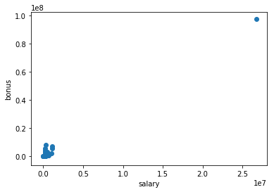

```python
features = ["salary", "bonus"]
data = featureFormat(data_dict, features)
for point in data:
    salary = point[0]
    bonus = point[1]
    plt.scatter( salary, bonus, c=base_color )

plt.xlabel("salary")
plt.ylabel("bonus")
plt.show()
```

```python
enron_df[enron_df['salary']>25000000]
```

|  | salary | to_messages | deferral_payments | total_payments | exercised_stock_options | bonus | restricted_stock | shared_receipt_with_poi | restricted_stock_deferred | total_stock_value | ... | from_messages | other | from_this_person_to_poi | poi | director_fees | deferred_income | long_term_incentive | from_poi_to_this_person | name | email_address |
| --- | --- | --- | --- | --- | --- | --- | --- | --- | --- | --- | --- | --- | --- | --- | --- | --- | --- | --- | --- | --- | --- |
| 104 | 26704229.0 | NaN | 32083396.0 | 309886585.0 | 311764000.0 | 97343619.0 | 130322299.0 | NaN | -7576788.0 | 434509511.0 | ... | NaN | 42667589.0 | NaN | 0.0 | 1398517.0 | -27992891.0 | 48521928.0 | NaN | TOTAL | NaN |

1 rows × 22 columns

Remove TOTAL from data

```python
data_dict.pop('TOTAL', 0)
enron_df=enron_df.drop(enron_df[enron_df['name']=='TOTAL'].index[0], axis=0)
```

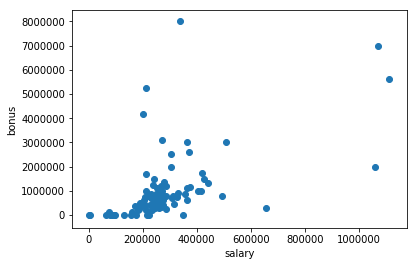

```python
features = ["salary", "bonus"]
data = featureFormat(data_dict, features)
for point in data:
    salary = point[0]
    bonus = point[1]
    plt.scatter( salary, bonus, c=base_color )

plt.xlabel("salary")
plt.ylabel("bonus")
plt.show()
```

Let's check other high values, it seems that it's real people, so we don't delete this points

```python
enron_df[enron_df['bonus']>5*10**6]
```

|  | salary | to_messages | deferral_payments | total_payments | exercised_stock_options | bonus | restricted_stock | shared_receipt_with_poi | restricted_stock_deferred | total_stock_value | ... | from_messages | other | from_this_person_to_poi | poi | director_fees | deferred_income | long_term_incentive | from_poi_to_this_person | name | email_address |
| --- | --- | --- | --- | --- | --- | --- | --- | --- | --- | --- | --- | --- | --- | --- | --- | --- | --- | --- | --- | --- | --- |
| 43 | 339288.0 | 7259.0 | NaN | 10425757.0 | 4158995.0 | 8000000.0 | 1008149.0 | 3962.0 | NaN | 5167144.0 | ... | 2585.0 | 1552.0 | 411.0 | 0.0 | NaN | NaN | 2035380.0 | 528.0 | LAVORATO JOHN J | john.lavorato@enron.com |
| 65 | 1072321.0 | 4273.0 | 202911.0 | 103559793.0 | 34348384.0 | 7000000.0 | 14761694.0 | 2411.0 | NaN | 49110078.0 | ... | 36.0 | 10359729.0 | 16.0 | 1.0 | NaN | -300000.0 | 3600000.0 | 123.0 | LAY KENNETH L | kenneth.lay@enron.com |
| 82 | 213999.0 | 7991.0 | 2144013.0 | 5501630.0 | 953136.0 | 5249999.0 | 157569.0 | 5521.0 | NaN | 1110705.0 | ... | 484.0 | 210698.0 | 108.0 | 1.0 | NaN | -2334434.0 | NaN | 228.0 | BELDEN TIMOTHY N | tim.belden@enron.com |
| 95 | 1111258.0 | 3627.0 | NaN | 8682716.0 | 19250000.0 | 5600000.0 | 6843672.0 | 2042.0 | NaN | 26093672.0 | ... | 108.0 | 22122.0 | 30.0 | 1.0 | NaN | NaN | 1920000.0 | 88.0 | SKILLING JEFFREY K | jeff.skilling@enron.com |

4 rows × 22 columns

'YEAP SOON' and 'THE TRAVEL AGENCY IN THE PARK' look like imaginary names, let's check

```python
data_dict['YEAP SOON']
```

```
{'bonus': 'NaN',
 'deferral_payments': 'NaN',
 'deferred_income': 'NaN',
 'director_fees': 'NaN',
 'email_address': 'NaN',
 'exercised_stock_options': 192758,
 'expenses': 55097,
 'from_messages': 'NaN',
 'from_poi_to_this_person': 'NaN',
 'from_this_person_to_poi': 'NaN',
 'loan_advances': 'NaN',
 'long_term_incentive': 'NaN',
 'other': 'NaN',
 'poi': False,
 'restricted_stock': 'NaN',
 'restricted_stock_deferred': 'NaN',
 'salary': 'NaN',
 'shared_receipt_with_poi': 'NaN',
 'to_messages': 'NaN',
 'total_payments': 55097,
 'total_stock_value': 192758}
```

```python
data_dict['THE TRAVEL AGENCY IN THE PARK']
```

```
{'bonus': 'NaN',
 'deferral_payments': 'NaN',
 'deferred_income': 'NaN',
 'director_fees': 'NaN',
 'email_address': 'NaN',
 'exercised_stock_options': 'NaN',
 'expenses': 'NaN',
 'from_messages': 'NaN',
 'from_poi_to_this_person': 'NaN',
 'from_this_person_to_poi': 'NaN',
 'loan_advances': 'NaN',
 'long_term_incentive': 'NaN',
 'other': 362096,
 'poi': False,
 'restricted_stock': 'NaN',
 'restricted_stock_deferred': 'NaN',
 'salary': 'NaN',
 'shared_receipt_with_poi': 'NaN',
 'to_messages': 'NaN',
 'total_payments': 362096,
 'total_stock_value': 'NaN'}
```

Let's delete this records as well

```python
data_dict.pop('THE TRAVEL AGENCY IN THE PARK', 0)
enron_df=enron_df.drop(enron_df[enron_df['name']=='THE TRAVEL AGENCY IN THE PARK'].index[0], axis=0)
data_dict.pop('YEAP SOON', 0)
enron_df=enron_df.drop(enron_df[enron_df['name']=='YEAP SOON'].index[0], axis=0)
```

```python
enron_df.columns
```

```
Index([u'salary', u'to_messages', u'deferral_payments', u'total_payments',
       u'exercised_stock_options', u'bonus', u'restricted_stock',
       u'shared_receipt_with_poi', u'restricted_stock_deferred',
       u'total_stock_value', u'expenses', u'loan_advances', u'from_messages',
       u'other', u'from_this_person_to_poi', u'poi', u'director_fees',
       u'deferred_income', u'long_term_incentive', u'from_poi_to_this_person',
       u'name', u'email_address'],
      dtype='object')
```

**Empty records**

```python
enron_df[enron_df.isna().sum(axis=1)/enron_df.shape[1]>0.8]
```

|  | salary | to_messages | deferral_payments | total_payments | exercised_stock_options | bonus | restricted_stock | shared_receipt_with_poi | restricted_stock_deferred | total_stock_value | ... | from_messages | other | from_this_person_to_poi | poi | director_fees | deferred_income | long_term_incentive | from_poi_to_this_person | name | email_address |
| --- | --- | --- | --- | --- | --- | --- | --- | --- | --- | --- | --- | --- | --- | --- | --- | --- | --- | --- | --- | --- | --- |
| 90 | NaN | NaN | NaN | NaN | NaN | NaN | NaN | NaN | NaN | NaN | ... | NaN | NaN | NaN | 0.0 | NaN | NaN | NaN | NaN | LOCKHART EUGENE E | NaN |

1 rows × 22 columns

'LOCKHART EUGENE E' record is empty, thus can be removed.

```python
enron_df.drop(enron_df[enron_df['name']=='LOCKHART EUGENE E'].index[0], inplace=True)
data_dict.pop('LOCKHART EUGENE E', 0)
```

```
{'bonus': 'NaN',
 'deferral_payments': 'NaN',
 'deferred_income': 'NaN',
 'director_fees': 'NaN',
 'email_address': 'NaN',
 'exercised_stock_options': 'NaN',
 'expenses': 'NaN',
 'from_messages': 'NaN',
 'from_poi_to_this_person': 'NaN',
 'from_this_person_to_poi': 'NaN',
 'loan_advances': 'NaN',
 'long_term_incentive': 'NaN',
 'other': 'NaN',
 'poi': False,
 'restricted_stock': 'NaN',
 'restricted_stock_deferred': 'NaN',
 'salary': 'NaN',
 'shared_receipt_with_poi': 'NaN',
 'to_messages': 'NaN',
 'total_payments': 'NaN',
 'total_stock_value': 'NaN'}
```

## 3. Create new feature(s)

to_poi_fraction, from_poi_fraction, salary/bonus_fraction

```python
enron_df['to_poi_fraction'] = enron_df['from_this_person_to_poi'] / enron_df['from_messages']
#enron_df['to_poi_fraction']=enron_df['to_poi_fraction'].fillna(0)
enron_df['to_poi_fraction'].replace(np.inf, 0, inplace=True)
enron_df[['to_poi_fraction','from_this_person_to_poi','from_messages'] ].head()
```

|  | to_poi_fraction | from_this_person_to_poi | from_messages |
| --- | --- | --- | --- |
| 0 | 0.034483 | 1.0 | 29.0 |
| 1 | NaN | NaN | NaN |
| 2 | NaN | NaN | NaN |
| 3 | 0.000000 | 0.0 | 12.0 |
| 4 | 0.656250 | 21.0 | 32.0 |

```python
for person in data_dict:
    if data_dict[person]['from_this_person_to_poi']=='NaN' or data_dict[person]['from_messages']=='NaN':
        data_dict[person]['to_poi_fraction']='NaN'
    else:
        data_dict[person]['to_poi_fraction'] = float(data_dict[person]['from_this_person_to_poi'])/float(data_dict[person]['from_messages'])
```

```python
enron_df['from_poi_fraction'] = enron_df['from_poi_to_this_person'] / enron_df['to_messages']
#enron_df['from_poi_fraction']=enron_df['from_poi_fraction'].fillna(0)
enron_df['from_poi_fraction'].replace(np.inf, 0, inplace=True)
enron_df[['from_poi_fraction','from_poi_to_this_person','to_messages'] ].head()
```

|  | from_poi_fraction | from_poi_to_this_person | to_messages |
| --- | --- | --- | --- |
| 0 | 0.047088 | 38.0 | 807.0 |
| 1 | NaN | NaN | NaN |
| 2 | NaN | NaN | NaN |
| 3 | 0.013089 | 10.0 | 764.0 |
| 4 | 0.030622 | 32.0 | 1045.0 |

```python
for person in data_dict:
    if data_dict[person]['from_poi_to_this_person']=='NaN' or data_dict[person]['to_messages']=='NaN':
        data_dict[person]['from_poi_fraction']='NaN'
    else:
        data_dict[person]['from_poi_fraction'] = float(data_dict[person]['from_poi_to_this_person'])/float(data_dict[person]['to_messages'])
```

```python
enron_df['salary_bonus_fraction']=enron_df['salary']/enron_df['bonus']
#enron_df['salary_bonus_fraction']=enron_df['salary_bonus_fraction'].fillna(0)
enron_df['salary_bonus_fraction'].replace(np.inf, 0, inplace=True)
enron_df[['salary_bonus_fraction', 'salary', 'bonus']].head()
```

|  | salary_bonus_fraction | salary | bonus |
| --- | --- | --- | --- |
| 0 | 0.609647 | 365788.0 | 600000.0 |
| 1 | 0.222585 | 267102.0 | 1200000.0 |
| 2 | 0.488403 | 170941.0 | 350000.0 |
| 3 | NaN | NaN | NaN |
| 4 | 0.162195 | 243293.0 | 1500000.0 |

```python
for person in data_dict:
    if data_dict[person]['salary']=='NaN' or data_dict[person]['bonus']=='NaN':
        data_dict[person]['salary_bonus_fraction']='NaN'
    else:
        data_dict[person]['salary_bonus_fraction'] = float(data_dict[person]['salary'])/float(data_dict[person]['bonus'])
```

```python
my_dataset=data_dict
```

```python
print len(features_list)
x=True
if x==True:
# add new features to features_list
    features_list.extend(['to_poi_fraction', 'from_poi_fraction', 'salary_bonus_fraction'])
    print features_list
len(features_list)
```

```
19
['salary', 'to_messages', 'deferral_payments', 'total_payments', 'exercised_stock_options', 'bonus', 'restricted_stock', 'shared_receipt_with_poi', 'restricted_stock_deferred', 'total_stock_value', 'expenses', 'loan_advances', 'from_messages', 'other', 'from_this_person_to_poi', 'director_fees', 'de…
```

```
22
```

'deffered_income' and 'restricted_stock_deffered' features are negarive, make it positive for SelectKbest

```python
enron_df['deferred_income']=-1*enron_df['deferred_income']
enron_df['restricted_stock_deferred']=-1*enron_df['restricted_stock_deferred']
enron_df['restricted_stock_deferred'].replace(-0.0, 0, inplace=True)
enron_df['deferred_income'].replace(-0.0, 0, inplace=True)
```

### Single variable visualisation

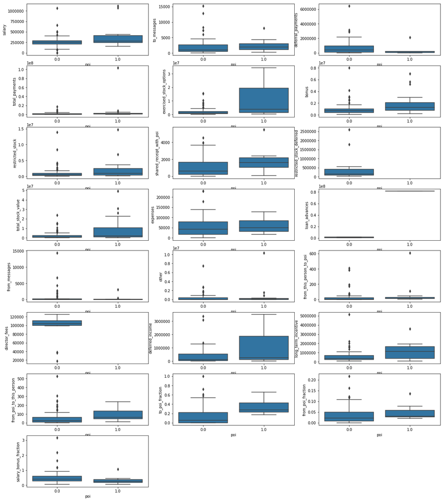

```python
numeric_columns=['salary', 'to_messages', 'deferral_payments', 'total_payments',
       'exercised_stock_options', 'bonus', 'restricted_stock',
       'shared_receipt_with_poi', 'restricted_stock_deferred',
       'total_stock_value', 'expenses', 'loan_advances', 'from_messages',
       'other', 'from_this_person_to_poi',  'director_fees',
       'deferred_income', u'long_term_incentive', 'from_poi_to_this_person',
       'to_poi_fraction', 'from_poi_fraction',
       'salary_bonus_fraction']
fig, ax = plt.subplots(8,3,figsize=(20,24))
fig.delaxes(ax[7,1])
fig.delaxes(ax[7,2])
k=0
for i in range(8):
    #print enron_df.columns[i]
    for j in range(3):
        enron_df.columns[j]
        sb.boxplot(data = enron_df, x = 'poi', y = numeric_columns[k],  color=base_color, ax=ax[i,j]);
        #ax[i,j].legend(loc=(0.01, 0.075) ,fontsize = 8);
        #ax[i.j].set_xlabel('principal component')
        #ax[1.1].set_title('Zoomed')
        k=k+1
        if k==22:
            break
```

'total_payments' are higher for POIs

```
(-1000000, 10000000)
```

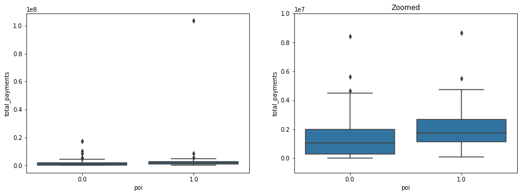

```python
fig, ax = plt.subplots(1,2,figsize=(15,5))
for i in range(2):
    sb.boxplot(data = enron_df, x = 'poi', y = 'total_payments',  color=base_color, ax=ax[i]);
ax[1].set_title('Zoomed')
ax[1].set_ylim(-1000000,10000000)
```

'from_messages' for non-POI are in higher range

```
(-100, 500)
```

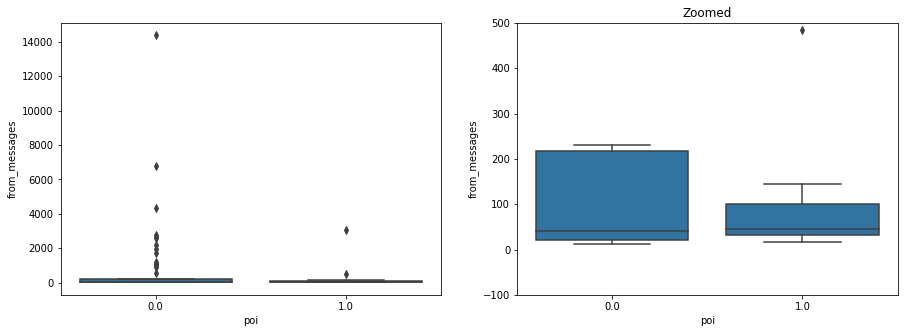

```python
fig, ax = plt.subplots(1,2,figsize=(15,5))
for i in range(2):
    sb.boxplot(data = enron_df, x = 'poi', y = 'from_messages',  color=base_color, ax=ax[i]);
ax[1].set_title('Zoomed')
ax[1].set_ylim(-100,500)
```

from_this_person_to_poi

```
(-10, 100)
```

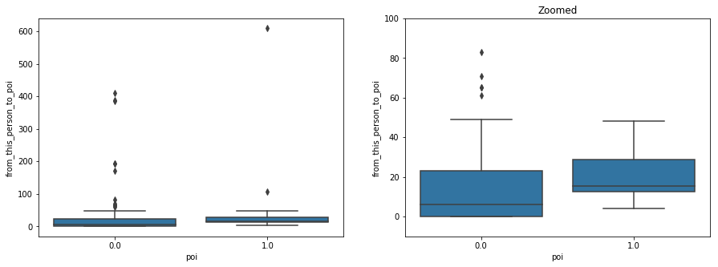

```python
fig, ax = plt.subplots(1,2,figsize=(15,5))
for i in range(2):
    sb.boxplot(data = enron_df, x = 'poi', y = 'from_this_person_to_poi',  color=base_color, ax=ax[i]);
ax[1].set_title('Zoomed')
ax[1].set_ylim(-10,100)
```

% of emptiness

```python
(enron_df[(enron_df==0)].count()+enron_df.isna().sum())/enron_df.shape[0]*100
```

```
salary                       33.802817
to_messages                  39.436620
deferral_payments            73.943662
total_payments               14.084507
exercised_stock_options      30.281690
bonus                        42.957746
restricted_stock             22.535211
shared_receipt_with_poi      39.436620
restricted_stock_deferred    88.028169
total_stock_value            12.676056
expenses                     33.098592
loan_advances                97.887324
from_messages                39.436620
other                        36.619718
from_this_person_to_poi      53.521127
poi                          87.323944
director_fees                89.436620
deferred_income              65.492958
long_term_incentive          54.225352
from_poi_to_this_person      47.887324
name                          0.000000
email_address                 0.000000
to_poi_fraction              53.521127
from_poi_fraction            47.887324
salary_bonus_fraction        42.957746
dtype: float64
```

Columns 'restricted_stock_deferred', 'loan_advances' and 'director_fees' are almost empty.

### Multi variable visualisation

Here I visualise the variables that will be selected further at the 'feature' selection step

```python
list_features_to_prin=['exercised_stock_options',  'to_poi_fraction',  'salary',  'bonus',  'deferred_income',
                        'from_poi_fraction', 'expenses']
```

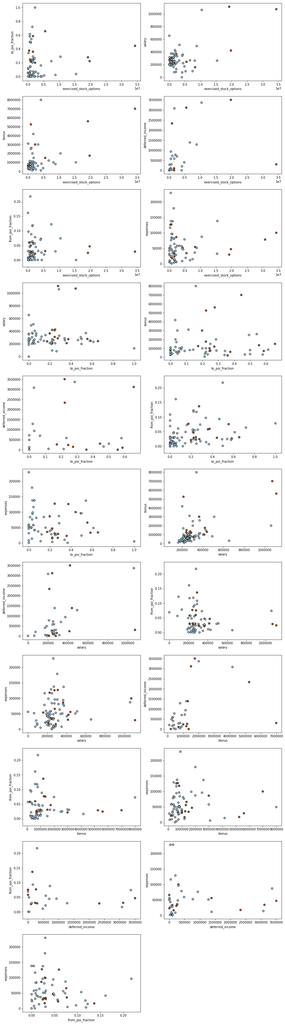

```python
k=0
fig, ax = plt.subplots(11,2,figsize=(15,60))
fig.delaxes(ax[10,1])
for feature1 in range(0,len(list_features_to_prin)):
    for feature2 in range(feature1+1, len(list_features_to_prin)):
        ax[k//2,k%2].scatter(enron_df[list_features_to_prin[feature1]], enron_df[list_features_to_prin[feature2]], c=enron_df['poi'],  cmap=plt.cm.Paired, edgecolors='k')
        ax[k//2,k%2].set_xlabel(list_features_to_prin[feature1])
        ax[k//2,k%2].set_ylabel(list_features_to_prin[feature2])
        k=k+1
```

exercised_stock_options' vs 'to_poi_fraction'

```
Text(0,0.5,'to_poi_fraction')
```

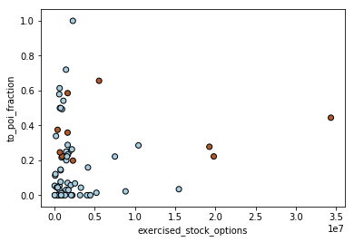

```python
# plot the samples
plt.scatter(enron_df['exercised_stock_options'], enron_df['to_poi_fraction'], c=enron_df['poi'],  cmap=plt.cm.Paired, edgecolors='k')
plt.xlabel('exercised_stock_options')
plt.ylabel('to_poi_fraction')
```

'salary' vs 'to_poi_fraction'

```
Text(0,0.5,'to_poi_fraction')
```

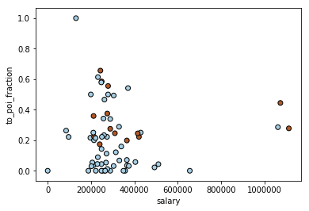

```python
# plot the samples
plt.scatter(enron_df['salary'], enron_df['to_poi_fraction'], c=enron_df['poi'],  cmap=plt.cm.Paired, edgecolors='k')
plt.xlabel('salary')
plt.ylabel('to_poi_fraction')
```

### Replace NANs with 0s

To use classification models we need to replace NANs with some values, since some of classification models can't handle NANs. Furthermore, we can;t just simply remove this column, as we have to many NANs in each column/row.

For simplisity we will replace NANs with 0s. Not the best way since we mnight loose a lot of valuable information by doing it.

The other simple option is to replace NANs with mean value of variable.

However, it's crucial step for good analysis, since we generate fake values in our data and it requires extra attention.

```python
enron_df.fillna(0, inplace=True)
```

### Split data to test train

```python
features_train, features_test, labels_train, labels_test = train_test_split(
    enron_df[features_list], enron_df['poi'], test_size=0.3, random_state=42)
```

```python
features_train.shape
```

```
(99, 22)
```

### Normalise train/test data: MinMaxScaler

```python
from sklearn.preprocessing import MinMaxScaler
mm_scaler = MinMaxScaler()
mm_scaler.fit(features_train[features_list])
features_train_norm=pd.DataFrame(mm_scaler.transform(features_train[features_list]),columns=features_list)
features_test_norm=pd.DataFrame(mm_scaler.transform(features_test[features_list]),columns=features_list)
```

## 4. Features selection

### PCA

Since PCA can work with missing number we will make temperary df with )s instead of NANs

```python
enron_df.describe()
```

|  | salary | to_messages | deferral_payments | total_payments | exercised_stock_options | bonus | restricted_stock | shared_receipt_with_poi | restricted_stock_deferred | total_stock_value | ... | other | from_this_person_to_poi | poi | director_fees | deferred_income | long_term_incentive | from_poi_to_this_person | to_poi_fraction | from_poi_fraction | salary_bonus_fraction |
| --- | --- | --- | --- | --- | --- | --- | --- | --- | --- | --- | --- | --- | --- | --- | --- | --- | --- | --- | --- | --- | --- |
| count | 1.420000e+02 | 142.000000 | 1.420000e+02 | 1.420000e+02 | 1.420000e+02 | 1.420000e+02 | 1.420000e+02 | 142.000000 | 1.420000e+02 | 1.420000e+02 | ... | 1.420000e+02 | 142.000000 | 142.000000 | 142.000000 | 1.420000e+02 | 1.420000e+02 | 142.000000 | 142.000000 | 142.000000 | 142.000000 |
| mean | 1.880580e+05 | 1256.000000 | 2.259394e+05 | 2.179362e+06 | 2.194164e+06 | 6.855184e+05 | 9.177627e+05 | 712.507042 | 5.335766e+04 | 3.058569e+06 | ... | 2.979260e+05 | 24.971831 | 0.126761 | 9848.711268 | 1.971330e+05 | 3.417037e+05 | 39.302817 | 0.111470 | 0.022992 | 0.276288 |
| std | 1.971843e+05 | 2248.476742 | 7.586983e+05 | 8.837746e+06 | 4.951890e+06 | 1.239221e+06 | 2.011567e+06 | 1081.626637 | 2.750417e+05 | 6.306116e+06 | ... | 1.138969e+06 | 80.287775 | 0.333882 | 30615.388119 | 6.096782e+05 | 6.908581e+05 | 74.657135 | 0.186784 | 0.036574 | 0.418177 |
| min | 0.000000e+00 | 0.000000 | 0.000000e+00 | 0.000000e+00 | 0.000000e+00 | 0.000000e+00 | 0.000000e+00 | 0.000000 | 0.000000e+00 | 0.000000e+00 | ... | 0.000000e+00 | 0.000000 | 0.000000 | 0.000000 | 0.000000e+00 | 0.000000e+00 | 0.000000 | 0.000000 | 0.000000 | 0.000000 |
| 25% | 0.000000e+00 | 0.000000 | 0.000000e+00 | 9.620200e+04 | 0.000000e+00 | 0.000000e+00 | 5.443750e+04 | 0.000000 | 0.000000e+00 | 3.248138e+05 | ... | 0.000000e+00 | 0.000000 | 0.000000 | 0.000000 | 0.000000e+00 | 0.000000e+00 | 0.000000 | 0.000000 | 0.000000 | 0.000000 |
| 50% | 2.112400e+05 | 391.500000 | 0.000000e+00 | 9.413595e+05 | 6.224980e+05 | 3.000000e+05 | 3.643740e+05 | 115.500000 | 0.000000e+00 | 9.860165e+05 | ... | 9.190000e+02 | 0.000000 | 0.000000 | 0.000000 | 0.000000e+00 | 0.000000e+00 | 5.500000 | 0.000000 | 0.005137 | 0.157692 |
| 75% | 2.708505e+05 | 1655.000000 | 9.684500e+03 | 1.917959e+06 | 1.714221e+06 | 8.000000e+05 | 8.651810e+05 | 1001.250000 | 0.000000e+00 | 2.453312e+06 | ... | 1.498310e+05 | 14.000000 | 0.000000 | 0.000000 | 4.052400e+04 | 3.750648e+05 | 41.750000 | 0.199609 | 0.030121 | 0.411267 |
| max | 1.111258e+06 | 15149.000000 | 6.426990e+06 | 1.035598e+08 | 3.434838e+07 | 8.000000e+06 | 1.476169e+07 | 5521.000000 | 2.604490e+06 | 4.911008e+07 | ... | 1.035973e+07 | 609.000000 | 1.000000 | 125034.000000 | 3.504386e+06 | 5.145434e+06 | 528.000000 | 1.000000 | 0.217341 | 3.157186 |

8 rows × 23 columns

```python
from sklearn.decomposition import PCA
from sklearn.preprocessing import MinMaxScaler

scaler = MinMaxScaler()
scaler.fit(enron_df[features_list])
enron_norm_df=pd.DataFrame(scaler.transform(enron_df[features_list]),columns=features_list)

pca= PCA()
pca.fit(enron_norm_df[features_list])
print(pca.explained_variance_ratio_)
```

```
[2.92315036e-01 1.24982715e-01 1.11601808e-01 8.82480433e-02
 7.13320777e-02 6.05962204e-02 4.41424667e-02 3.72493254e-02
 3.03144090e-02 2.65936961e-02 2.32942324e-02 1.90231007e-02
 1.57741873e-02 1.38876259e-02 1.31332660e-02 9.65596437e-03
 6.99145948e-03 5.45865070e-03 3.21144151e-03 2.19427329e-03
 1.23433400e-33 2.84401922e-34]
```

```
(0.01, 1)
```

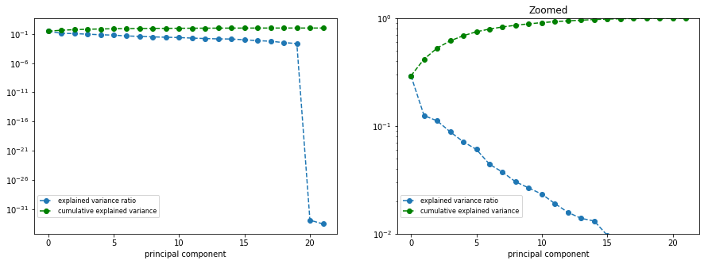

```python
fig, ax = plt.subplots(1,2,figsize=(15,5))
for i in range(2):
    ax[i].semilogy(pca.explained_variance_ratio_, '--o', label = 'explained variance ratio')
    ax[i].semilogy(pca.explained_variance_ratio_.cumsum(), '--go',
                   label = 'cumulative explained variance');
    ax[i].legend(loc=(0.01, 0.075) ,fontsize = 8);
    ax[i].set_xlabel('principal component')
ax[1].set_title('Zoomed')

ax[1].set_ylim(0.01,1)
```

```python
pca.explained_variance_ratio_.cumsum()
```

```
array([0.29231504, 0.41729775, 0.52889956, 0.6171476 , 0.68847968,
       0.7490759 , 0.79321837, 0.83046769, 0.8607821 , 0.8873758 ,
       0.91067003, 0.92969313, 0.94546732, 0.95935494, 0.97248821,
       0.98214418, 0.98913563, 0.99459429, 0.99780573, 1.        ,
       1.        , 1.        ])
```

We can see that the first eight (8) principal components explain more than 80% of variance. So we dodn't need to base our classification on all 22 variables, but we can use only 8 principle components. Unforturnately, principle cmponents are not so easy to interprete, as each picnipal component consists of linear combination of original variables.

### Filter Methods for features selection

```python
correlated_features = set()
correlation_matrix = features_train.corr()
#correlation_matrix
```

Let's see the total number of columns in our dataset, with correlation value greater than 0.8 with at least 1 other column.

```python
for i in range(len(correlation_matrix .columns)):
    for j in range(i):
        #print correlation_matrix.columns[i], correlation_matrix.columns[j]
        if abs(correlation_matrix.iloc[i, j]) > 0.8:
            colname = correlation_matrix.columns[i]
            print correlation_matrix.columns[i], " & ", correlation_matrix.columns[j]
            correlated_features.add(colname)
correlated_features
```

```
shared_receipt_with_poi  &  to_messages
total_stock_value  &  exercised_stock_options
from_this_person_to_poi  &  to_messages
from_poi_to_this_person  &  shared_receipt_with_poi
```

```
{'from_poi_to_this_person',
 'from_this_person_to_poi',
 'shared_receipt_with_poi',
 'total_stock_value'}
```

remove correlated features: 'from_this_person_to_poi', 'from_this_person_to_poi', 'shared_receipt_with_poi' and 'total_stock_value' from features list

```python
for feature_to_remove in correlated_features:
    features_list.remove(feature_to_remove)
```

```python
len(features_list)
```

```
18
```

### Wrapper Methods for Feature Selection

```python
features_importance=[]
from sklearn.feature_selection import SelectKBest, chi2
skbest = SelectKBest(k="all")  # try best value to fit
sk_transform = skbest.fit_transform(features_train[features_list], labels_train)
indices = skbest.get_support(True)
features_subset = []
for index in indices:
    print '%s : %f' % (features_list[index], skbest.scores_[index])
    features_importance.append([features_list[index], skbest.scores_[index]])
    features_subset.append(features_list[index] )
```

```
salary : 7.482884
to_messages : 0.410569
deferral_payments : 0.113102
total_payments : 1.255838
exercised_stock_options : 13.218728
bonus : 6.723639
restricted_stock : 1.485720
restricted_stock_deferred : 1.187182
expenses : 2.866811
loan_advances : 0.208430
from_messages : 0.774678
other : 0.000681
director_fees : 1.831828
deferred_income : 5.634510
long_term_incentive : 1.564902
to_poi_fraction : 11.178661
from_poi_fraction : 3.615350
salary_bonus_fraction : 0.000000
```

Top 7 variables are:

```python
pd.DataFrame(features_importance).sort_values(1, ascending=False).head(7)[0].tolist()[0:7]
```

```
['exercised_stock_options',
 'to_poi_fraction',
 'salary',
 'bonus',
 'deferred_income',
 'from_poi_fraction',
 'expenses']
```

```python
features_subset7=pd.DataFrame(features_importance).sort_values(1, ascending=False).head(7)[0].tolist()[0:7]
features_subset5=features_subset7[0:5]
features_subset3=features_subset7[0:3]
features_subset2=features_subset7[0:2]
```

```python
# check for columns correlation (just double check)
correlated_features = set()
correlation_matrix = features_train[features_subset7].corr()
for i in range(len(correlation_matrix.columns)):
    for j in range(i):
        if abs(correlation_matrix.iloc[i, j]) > 0.8:
            colname = correlation_matrix.columns[i]
            correlated_features.add(colname)
correlated_features
```

```
set()
```

## 4. Try a varity of classifiers

The **precision** is the ratio tp / (tp + fp) where tp is the number of true positives and fp the number of false positives. The precision is intuitively the ability of the classifier not to label as positive a sample that is negative.

The **recall** is the ratio tp / (tp + fn). The recall is intuitively the ability of the classifier to find all the positive samples.

The best value is 1 and the worst value is 0.

```python
def print_prec_recall(clf, X_train, y_train, X_test, y_test, text):

    #print "Train acc\t Train prec\t Train recall"
    pred=clf.predict(X_train)
    train_acc=accuracy_score(pred, y_train)
    train_prec=precision_score(y_train, pred)
    train_rec=recall_score(y_train, pred)
    pred=clf.predict(X_test)
    test_acc=accuracy_score(pred, y_test)
    test_prec=precision_score(y_test, pred)
    test_rec=recall_score(y_test, pred)

    head = "num_var\ttrain_accuracy\ttrain_precision\ttrain_recall\ttest_accuracy\ttest_precision\ttest_recall\n"
    fmt = "{num_var:s}\t{train_accuracy:0.4f}\t\t{train_precision:0.4f}\t\t{train_recall:0.4f}\t\t{test_accuracy:0.4f}\t\t{test_precision:0.4f}\t\t{test_recall:0.4f}"
    print fmt.format(num_var=text, train_accuracy=train_acc, train_precision=train_prec,  train_recall=train_rec, test_accuracy=test_acc, test_precision=test_prec,  test_recall=test_rec)
```

### 4.1.1 Gaussian

```python
from sklearn.naive_bayes import GaussianNB
gauss = GaussianNB()
head = "num_var\ttrain_accuracy\ttrain_precision\ttrain_recall\ttest_accuracy\ttest_precision\ttest_recall"
print "Gaussian"
print head
gauss.fit(features_train_norm[features_subset7], labels_train)
print_prec_recall(gauss, features_train_norm[features_subset7], labels_train, features_test_norm[features_subset7], labels_test, '7_var')
gauss.fit(features_train_norm[features_subset5], labels_train)
print_prec_recall(gauss, features_train_norm[features_subset5], labels_train, features_test_norm[features_subset5], labels_test, '5_var')
gauss.fit(features_train_norm[features_subset3], labels_train)
print_prec_recall(gauss, features_train_norm[features_subset3], labels_train, features_test_norm[features_subset3], labels_test, '3_var')
gauss.fit(features_train_norm[features_subset2], labels_train)
print_prec_recall(gauss, features_train_norm[features_subset2], labels_train, features_test_norm[features_subset2], labels_test, '2_var')
```

```
Gaussian
num_var	train_accuracy	train_precision	train_recall	test_accuracy	test_precision	test_recall
7_var	0.8586		0.4545		0.3846		0.8140		0.2857		0.4000
5_var	0.8586		0.4444		0.3077		0.8372		0.3333		0.4000
3_var	0.8687		0.5000		0.3846		0.8372		0.3333		0.4000
2_var	0.8687		0.5000		0.3846		0.8605		0.4000		0.4000
```

the same but using pipeline for normalisation

```python
from sklearn.pipeline import Pipeline
from sklearn.preprocessing import MinMaxScaler
from sklearn.naive_bayes import GaussianNB

print "Gaussian"
print head
clf_Gaus =  Pipeline([('scaler', MinMaxScaler()), ('GaussianNB', GaussianNB())])

clf_Gaus.fit(features_train_norm[features_subset7], labels_train)
print_prec_recall(clf_Gaus, features_train_norm[features_subset7], labels_train, features_test_norm[features_subset7], labels_test, '7_var')
clf_Gaus.fit(features_train_norm[features_subset5], labels_train)
print_prec_recall(clf_Gaus, features_train_norm[features_subset5], labels_train, features_test_norm[features_subset5], labels_test, '5_var')
clf_Gaus.fit(features_train_norm[features_subset3], labels_train)
print_prec_recall(clf_Gaus, features_train_norm[features_subset3], labels_train, features_test_norm[features_subset3], labels_test, '3_var')
clf_Gaus.fit(features_train_norm[features_subset2], labels_train)
print_prec_recall(clf_Gaus, features_train_norm[features_subset2], labels_train, features_test_norm[features_subset2], labels_test, '2_var')
```

```
Gaussian
num_var	train_accuracy	train_precision	train_recall	test_accuracy	test_precision	test_recall
7_var	0.8586		0.4545		0.3846		0.8140		0.2857		0.4000
5_var	0.8586		0.4444		0.3077		0.8372		0.3333		0.4000
3_var	0.8687		0.5000		0.3846		0.8372		0.3333		0.4000
2_var	0.8687		0.5000		0.3846		0.8605		0.4000		0.4000
```

### 4.2 Decision tree classifier

```python
from sklearn import tree
from sklearn.tree import DecisionTreeClassifier


print "Decision tree classifier"
print head
tree = tree.DecisionTreeClassifier(random_state=43)

tree.fit(features_train_norm[features_subset7], labels_train)
print_prec_recall(tree, features_train_norm[features_subset7], labels_train, features_test_norm[features_subset7], labels_test, '7_var')
tree.fit(features_train_norm[features_subset5], labels_train)
print_prec_recall(tree, features_train_norm[features_subset5], labels_train, features_test_norm[features_subset5], labels_test, '5_var')
tree.fit(features_train_norm[features_subset3], labels_train)
print_prec_recall(tree, features_train_norm[features_subset3], labels_train, features_test_norm[features_subset3], labels_test, '3_var')
tree.fit(features_train_norm[features_subset2], labels_train)
print_prec_recall(tree, features_train_norm[features_subset2], labels_train, features_test_norm[features_subset2], labels_test, '2_var')
```

```
Decision tree classifier
num_var	train_accuracy	train_precision	train_recall	test_accuracy	test_precision	test_recall
7_var	1.0000		1.0000		1.0000		0.9070		0.5714		0.8000
5_var	1.0000		1.0000		1.0000		0.7907		0.2500		0.4000
3_var	1.0000		1.0000		1.0000		0.7442		0.2500		0.6000
2_var	0.9798		1.0000		0.8462		0.8605		0.4000		0.4000
```

### 4.3 SVM

```python
set1=['to_poi_fraction', 'exercised_stock_options']
```

Doesn't work on normalised data

```python
from sklearn.svm import SVC

svc_n = SVC(kernel="linear", max_iter=1000)

svc_n.fit(features_train_norm[features_subset7], labels_train)
print svc_n.predict(features_train_norm[features_subset7])
print svc_n.predict(features_test_norm[features_subset7])

print "SVC"
print head
print_prec_recall(svc_n, features_train_norm[features_subset7], labels_train, features_test_norm[features_subset7], labels_test, '7_var')
svc_n.fit(features_train_norm[features_subset5], labels_train)
print_prec_recall(svc_n, features_train_norm[features_subset5], labels_train, features_test_norm[features_subset5], labels_test, '5_var')
svc_n.fit(features_train_norm[features_subset3], labels_train)
print_prec_recall(svc_n, features_train_norm[features_subset3], labels_train, features_test_norm[features_subset3], labels_test, '3_var')
svc_n.fit(features_train_norm[features_subset2], labels_train)
print_prec_recall(svc_n, features_train_norm[features_subset2], labels_train, features_test_norm[features_subset2], labels_test, '2_var')
```

```
[0. 0. 0. 0. 0. 0. 0. 0. 0. 0. 0. 0. 0. 0. 0. 0. 0. 0. 0. 0. 0. 0. 0. 0.
 0. 0. 0. 0. 0. 0. 0. 0. 0. 0. 0. 0. 0. 0. 0. 0. 0. 0. 0. 0. 0. 0. 0. 0.
 0. 0. 0. 0. 0. 0. 0. 0. 0. 0. 0. 0. 0. 0. 0. 0. 0. 0. 0. 0. 0. 0. 0. 0.
 0. 0. 0. 0. 0. 0. 0. 0. 0. 0. 0. 0. 0. 0. 0. 0. 0. 0. 0. 0. 0. 0. 0. 0.
 0. 0. 0.]
[0. 0. 0. 0. 0. 0. 0. 0. 0. 0. 0. 0. 0. 0. 0. 0. 0. 0. 0. 0. 0. 0. 0. 0.
 0. 0. 0. 0. 0. 0. 0. 0. 0. 0. 0. 0. 0. 0. 0. 0. 0. 0. 0.]
SVC
num_var	train_accuracy	train_precision	train_recall	test_accuracy	test_precision	test_recall
7_var	0.8687		0.0000		0.0000		0.8837		0.0000		0.0000
5_var	0.8687		0.0000		0.0000		0.8837		0.0000		0.0000
3_var	0.8687		0.0000		0.0000		0.8837		0.0000		0.0000
2_var	0.8687		0.0000		0.0000		0.8837		0.0000		0.0000
```

[output not shown]

When no data points are classified as positive, precision divides by zero as it is defined as TP / (TP + FP) (i.e., true positives / true and false positives). The library then sets precision to 0, but issues a warning as actually the value is undefined.

**However very badly but works on the original data ????**

```python
from sklearn.svm import SVC

svc = SVC(kernel="linear", max_iter=1000)

svc.fit(features_train[features_subset7], labels_train)
print svc.predict(features_train[features_subset7])
print svc.predict(features_test[features_subset7])

print "SVC"
print head
print_prec_recall(svc, features_train[features_subset7], labels_train, features_test[features_subset7], labels_test, '7_var')
svc.fit(features_train[features_subset5], labels_train)
print_prec_recall(svc, features_train[features_subset5], labels_train, features_test[features_subset5], labels_test, '5_var')
svc.fit(features_train[features_subset3], labels_train)
print_prec_recall(svc, features_train[features_subset3], labels_train, features_test[features_subset3], labels_test, '3_var')
svc.fit(features_train[features_subset2], labels_train)
print_prec_recall(svc, features_train[features_subset2], labels_train, features_test[features_subset2], labels_test, '2_var')
```

```
[1. 0. 0. 0. 0. 1. 0. 0. 0. 0. 0. 1. 0. 0. 0. 0. 1. 0. 0. 1. 0. 0. 0. 1.
 0. 0. 0. 0. 0. 0. 1. 0. 1. 0. 0. 0. 1. 1. 0. 0. 0. 1. 0. 1. 0. 1. 1. 0.
 0. 0. 0. 0. 0. 0. 1. 0. 0. 0. 0. 0. 0. 0. 1. 0. 0. 1. 0. 0. 0. 0. 1. 1.
 1. 1. 0. 0. 1. 0. 0. 0. 0. 0. 0. 0. 1. 0. 0. 0. 0. 0. 0. 1. 0. 0. 0. 1.
 0. 0. 0.]
[0. 0. 0. 0. 0. 0. 0. 1. 0. 0. 0. 0. 0. 1. 0. 0. 0. 0. 1. 0. 0. 0. 0. 0.
 0. 0. 0. 1. 0. 0. 0. 0. 0. 0. 0. 0. 0. 0. 0. 0. 0. 1. 0.]
SVC
num_var	train_accuracy	train_precision	train_recall	test_accuracy	test_precision	test_recall
7_var	0.7172		0.2000		0.3846		0.9070		0.6000		0.6000
```

[output not shown]

```
5_var	0.2424		0.1026		0.6154		0.0930		0.0526		0.4000
3_var	0.2525		0.1139		0.6923		0.1163		0.0769		0.6000
2_var	0.2323		0.1111		0.6923		0.1163		0.0769		0.6000
```

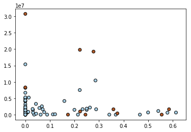

```python
# plot the samples
plt.scatter(features_train['to_poi_fraction'], features_train['exercised_stock_options'], c=labels_train,  cmap=plt.cm.Paired, edgecolors='k')
```

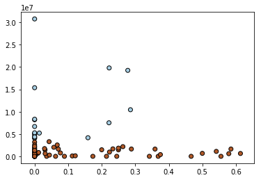

```python
# plot the samples
pred=svc.predict(features_train[features_subset2])
plt.scatter(features_train['to_poi_fraction'], features_train['exercised_stock_options'], c=pred, cmap=plt.cm.Paired, edgecolors='k')
```

Do I always have to perform scaling? ref. https://stats.stackexchange.com/questions/172795/scaling-for-svm-destroys-my-results/172864#172864

### 4.4 KNeighborsClassifier

```python
from sklearn.neighbors import KNeighborsClassifier

print "KNeighborsClassifier"
print head
kn = KNeighborsClassifier()#algorithm='kd_tree',n_neighbors=2, weights='distance')
kn.fit(features_train_norm[features_subset7], labels_train)
print_prec_recall(kn, features_train_norm[features_subset7], labels_train, features_test_norm[features_subset7], labels_test, '7_var')
kn.fit(features_train_norm[features_subset5], labels_train)
print_prec_recall(kn, features_train_norm[features_subset5], labels_train, features_test_norm[features_subset5], labels_test, '5_var')
kn.fit(features_train_norm[features_subset3], labels_train)
print_prec_recall(kn, features_train_norm[features_subset3], labels_train, features_test_norm[features_subset3], labels_test, '3_var')
kn.fit(features_train_norm[features_subset2], labels_train)
print_prec_recall(kn, features_train_norm[features_subset2], labels_train, features_test_norm[features_subset2], labels_test, '2_var')
```

```
KNeighborsClassifier
num_var	train_accuracy	train_precision	train_recall	test_accuracy	test_precision	test_recall
7_var	0.8687		0.5000		0.1538		0.9070		1.0000		0.2000
5_var	0.8485		0.0000		0.0000		0.9070		1.0000		0.2000
3_var	0.8788		1.0000		0.0769		0.9070		1.0000		0.2000
2_var	0.8788		1.0000		0.0769		0.9070		1.0000		0.2000
```

### 4.5 Random forest

```python
from sklearn.ensemble import RandomForestClassifier
from sklearn.datasets import make_classification

print "Random forest"
print head

forest = RandomForestClassifier(random_state=6)
forest.fit(features_train_norm[features_subset7], labels_train)
print_prec_recall(forest, features_train_norm[features_subset7], labels_train, features_test_norm[features_subset7], labels_test, '7_var')
forest.fit(features_train_norm[features_subset5], labels_train)
print_prec_recall(forest, features_train_norm[features_subset5], labels_train, features_test_norm[features_subset5], labels_test, '5_var')
forest.fit(features_train_norm[features_subset3], labels_train)
print_prec_recall(forest, features_train_norm[features_subset3], labels_train, features_test_norm[features_subset3], labels_test, '3_var')
forest.fit(features_train_norm[features_subset2], labels_train)
print_prec_recall(forest, features_train_norm[features_subset2], labels_train, features_test_norm[features_subset2], labels_test, '2_var')
```

```
Random forest
num_var	train_accuracy	train_precision	train_recall	test_accuracy	test_precision	test_recall
7_var	1.0000		1.0000		1.0000		0.9070		1.0000		0.2000
```

```
5_var	0.9697		1.0000		0.7692		0.9535		1.0000		0.6000
3_var	0.9899		1.0000		0.9231		0.8605		0.0000		0.0000
2_var	0.9495		1.0000		0.6154		0.8837		0.0000		0.0000
```

### 4.6 Adaboost (boosted decision tree)

```python
from sklearn.ensemble import AdaBoostClassifier
from sklearn.datasets import make_gaussian_quantiles

print "Adaboost"
print head

ada = AdaBoostClassifier(DecisionTreeClassifier(max_depth=1),
                         algorithm="SAMME",
                         n_estimators=200)
ada.fit(features_train_norm[features_subset7], labels_train)
print_prec_recall(ada, features_train_norm[features_subset7], labels_train, features_test_norm[features_subset7], labels_test, '7_var')
ada.fit(features_train_norm[features_subset5], labels_train)
print_prec_recall(ada, features_train_norm[features_subset5], labels_train, features_test_norm[features_subset5], labels_test, '5_var')
ada.fit(features_train_norm[features_subset3], labels_train)
print_prec_recall(ada, features_train_norm[features_subset3], labels_train, features_test_norm[features_subset3], labels_test, '3_var')
ada.fit(features_train_norm[features_subset2], labels_train)
print_prec_recall(ada, features_train_norm[features_subset2], labels_train, features_test_norm[features_subset2], labels_test, '2_var')
```

```
Adaboost
num_var	train_accuracy	train_precision	train_recall	test_accuracy	test_precision	test_recall
7_var	1.0000		1.0000		1.0000		0.9302		0.7500		0.6000
5_var	1.0000		1.0000		1.0000		0.8140		0.2857		0.4000
3_var	1.0000		1.0000		1.0000		0.9070		0.6667		0.4000
2_var	0.9596		0.9091		0.7692		0.8837		0.5000		0.2000
```

## 5. Tune your classifier to achieve better than .3 precision and recall

Tuning is performed by GridSearchCV

```python
from sklearn.metrics import make_scorer
scorers = {
    'precision_score': make_scorer(precision_score),
    'recall_score': make_scorer(recall_score)
}
```

### 5.1Tuned DecisionTree Classifier

We will ture 'max_sample_split' and 'max_depth'

```python
from sklearn.model_selection import GridSearchCV
import warnings
warnings.filterwarnings(action='once')
parameters = {'criterion':('gini', 'entropy'), 'min_samples_split': range (2, 10, 1), 'max_depth': range(5,10,1)}
tree = DecisionTreeClassifier(random_state=43)
clf_tree=GridSearchCV(tree, parameters, scoring =scorers, refit='precision_score')
clf_tree.fit(features_train_norm[features_subset7], labels_train)
#print sorted(clf.cv_results_.keys())
print head
print_prec_recall(clf_tree, features_train_norm[features_subset7], labels_train, features_test_norm[features_subset7], labels_test, '7_var')
clf_tree.best_estimator_
```

```
num_var	train_accuracy	train_precision	train_recall	test_accuracy	test_precision	test_recall
7_var	1.0000		1.0000		1.0000		0.9070		0.5714		0.8000
```

```
DecisionTreeClassifier(class_weight=None, criterion='entropy', max_depth=6,
            max_features=None, max_leaf_nodes=None,
            min_impurity_decrease=0.0, min_impurity_split=None,
            min_samples_leaf=1, min_samples_split=2,
            min_weight_fraction_leaf=0.0, presort=False, random_state=43,
            splitter='best')
```

Loop through all values of 'max_depth' to visualise the accuracy/precision/recall

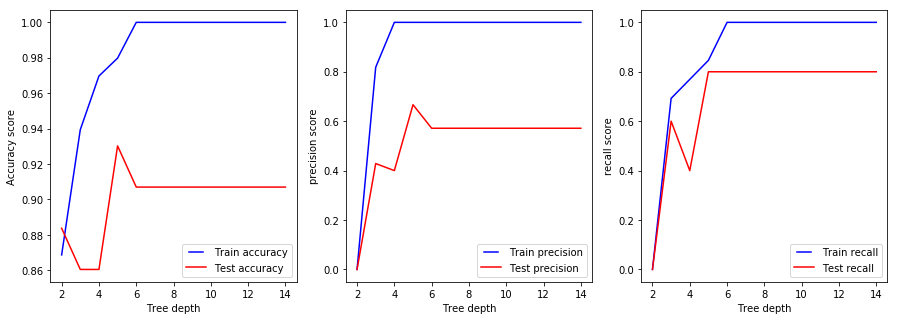

```python
params = range (2, 15, 1)
train_accuracy_results = []
test_accuracy_results = []
train_precision_results = []
test_precision_results = []
train_recall_results = []
test_recall_results = []
for param in params:
    dt = DecisionTreeClassifier(criterion='entropy', max_depth=param, random_state=43)
    dt.fit(features_train_norm[features_subset7], labels_train)

    train_pred = dt.predict(features_train_norm[features_subset7])
    acc=accuracy_score(train_pred, labels_train)
    prec=precision_score(labels_train, train_pred)
    rec=recall_score(labels_train, train_pred)
    train_accuracy_results.append(acc)
    train_precision_results.append(prec)
    train_recall_results.append(rec)

    test_pred = dt.predict(features_test_norm[features_subset7])
    acc=accuracy_score(test_pred, labels_test)
    prec=precision_score(labels_test, test_pred)
    rec=recall_score(labels_test, test_pred)
    test_accuracy_results.append(acc)
    test_precision_results.append(prec)
    test_recall_results.append(rec)

from matplotlib.legend_handler import HandlerLine2D
fig, ax = plt.subplots(1,3,figsize=(15,5))
line1, = ax[0].plot(params, train_accuracy_results, 'b', label='Train accuracy')
line2, = ax[0].plot(params, test_accuracy_results, 'r', label='Test accuracy')
ax[0].legend(handler_map={line1: HandlerLine2D(numpoints=2)})
ax[0].set_ylabel('Accuracy score')
ax[0].set_xlabel('Tree depth')

line1, = ax[1].plot(params, train_precision_results, 'b', label='Train precision')
line2, = ax[1].plot(params, test_precision_results, 'r', label='Test precision')
ax[1].legend(handler_map={line1: HandlerLine2D(numpoints=2)})
ax[1].set_ylabel('precision score')
ax[1].set_xlabel('Tree depth')

line1, = ax[2].plot(params, train_recall_results, 'b', label='Train recall')
line2, = ax[2].plot(params, test_recall_results, 'r', label='Test recall')
ax[2].legend(handler_map={line1: HandlerLine2D(numpoints=2)})
ax[2].set_ylabel('recall score')
ax[2].set_xlabel('Tree depth')
plt.show()
```

### 5.2 Tuned KNeighborsClassifier

```python
from sklearn.model_selection import GridSearchCV
warnings.filterwarnings(action='once')
parameters = {'n_neighbors': range(1, 15, 1), "n_jobs": [1,2,4,6,8], 'algorithm' : ('auto', 'ball_tree', 'kd_tree') }
kn = KNeighborsClassifier()
clf_kn=GridSearchCV(kn, parameters,scoring =scorers, refit='precision_score')
clf_kn.fit(features_train_norm[features_subset3], labels_train)
print head
print_prec_recall(clf_kn, features_train_norm[features_subset3], labels_train, features_test_norm[features_subset3], labels_test, "3_var")
clf_kn.best_estimator_
```

```
num_var	train_accuracy	train_precision	train_recall	test_accuracy	test_precision	test_recall
3_var	0.8990		0.7143		0.3846		0.8837		0.5000		0.2000
```

```
KNeighborsClassifier(algorithm='auto', leaf_size=30, metric='minkowski',
           metric_params=None, n_jobs=1, n_neighbors=3, p=2,
           weights='uniform')
```

### 5.3 Tuned Random Forest

```python
parameters = { 'n_estimators':[1,2,4,8,16], 'min_samples_split': range (2, 10, 1), 'max_depth': range(5,10,1)}
forest = RandomForestClassifier(criterion='entropy', random_state=6)
clf_forest=GridSearchCV(forest, parameters,scoring =scorers, refit='precision_score')
clf_forest.fit(features_train_norm[features_subset5], labels_train)
#print sorted(clf.cv_results_.keys())
print head
print_prec_recall(clf_forest, features_train_norm[features_subset5], labels_train, features_test_norm[features_subset5], labels_test, '5_var')
clf_forest.best_estimator_
```

```
num_var	train_accuracy	train_precision	train_recall	test_accuracy	test_precision	test_recall
5_var	0.9798		1.0000		0.8462		0.9535		1.0000		0.6000
```

```
RandomForestClassifier(bootstrap=True, class_weight=None, criterion='entropy',
            max_depth=5, max_features='auto', max_leaf_nodes=None,
            min_impurity_decrease=0.0, min_impurity_split=None,
            min_samples_leaf=1, min_samples_split=3,
            min_weight_fraction_leaf=0.0, n_estimators=16, n_jobs=None,
            oob_score=False, random_state=6, verbose=0, warm_start=False)
```

## 6. Dump your classifier, dataset, and features_list

```python
clf=ada
features_list=['poi'] + features_subset7
```

```python
clf.fit(features_train_norm[features_subset7], labels_train)
print_prec_recall(clf, features_train_norm[features_subset7], labels_train, features_test_norm[features_subset7], labels_test, '7_var')
```

```
7_var	1.0000		1.0000		1.0000		0.9302		0.7500		0.6000
```

```python
clf.feature_importances_
```

```
array([0.14636964, 0.0823331 , 0.12645594, 0.04260215, 0.1163551 ,
       0.03558974, 0.45029432])
```

features importance

```python
for i in range(0,len(clf.feature_importances_)):
    if clf.feature_importances_[i] > 0.1:
        print i, clf.feature_importances_[i]
```

```
0 0.1463696401142001
2 0.12645594470357616
4 0.1163551041446582
6 0.4502943188196983
```

```python
### Task 6: Dump your classifier, dataset, and features_list so anyone can
### check your results. You do not need to change anything below, but make sure
### that the version of poi_id.py that you submit can be run on its own and
### generates the necessary .pkl files for validating your results.

dump_classifier_and_data(clf, my_dataset, features_list)
```